# Ford Go Bike Rental Visual Exploration

## by Salma ElSayed

## Investigation Overview

> The overall goal is to look into the variables that influence the amount of bike rentals using the Ford Go dataset.

## Dataset Overview

> The dataset presents 183412 records of rentals giving data on time and location of rentals and some basic demographics of users. There are also two types of users: subscribers and customers.

## 1. Rentals Across Weekdays

> This plot shows how rental numbers vary between weekdays and weekends and it also shows the difference for subscribers and customers. We can see weekends have much less rentals for subscribers but no difference for customers.

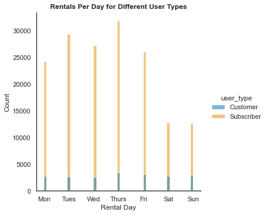

## 2. Rentals Across The Day

> We can observe here that the two peaks for rental activity are in the morning around 8:00 and in the afternoon around 17:00.

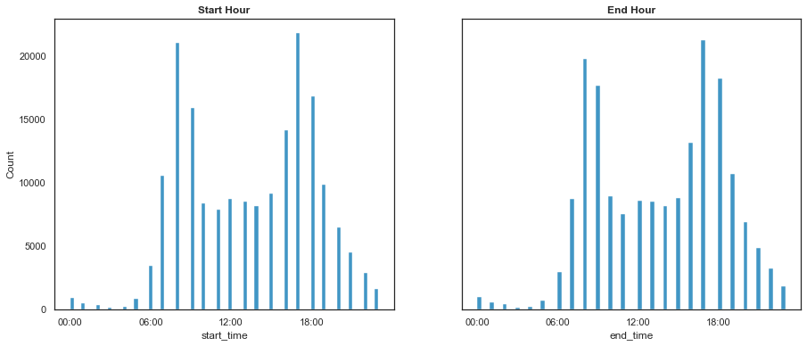

## 3. Gender and Weekly Rental Pattern

> We can here observe that there is no difference in activity across the week between users of different genders.

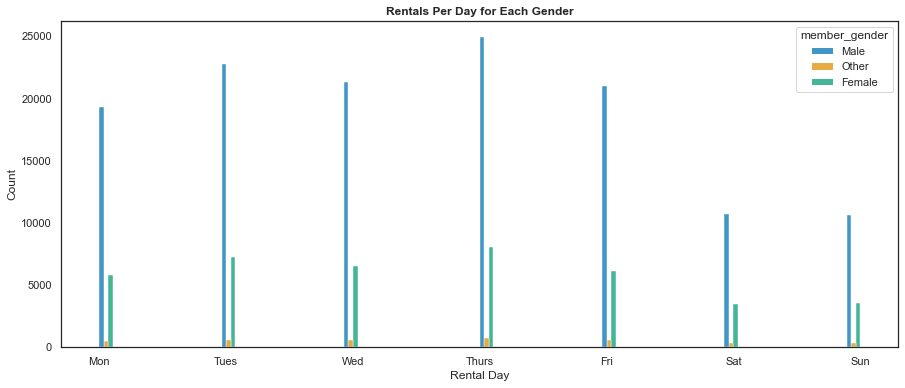

## 4. Region and Trip Duration

> In some regions, stations rented bikes for longer durations than others. This plot shows the locations of the stations plotted with their longitude and latitue coordinates and the duration of the trips at each coordinate is expressed with the size of the marker where a larger marker indicates a longer trip duration.

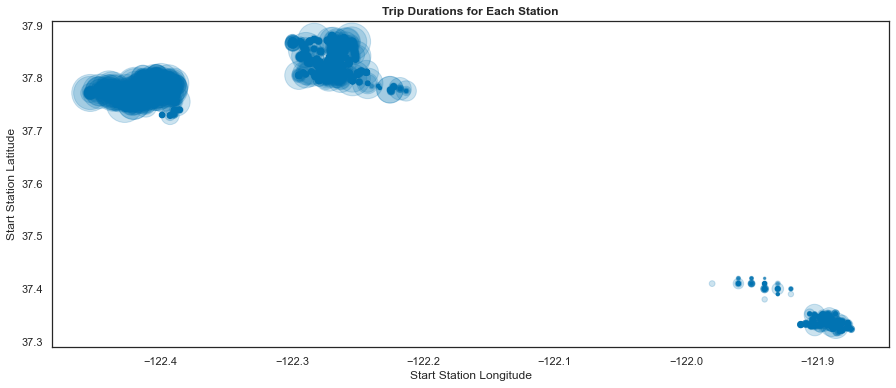

## 5. Region and Weekly Rental Pattern

> In this diagram, stations were divided into the 3 regions based on the clustered appearance of their distribution. The rental patterns across the week of different regions are shown below. We can also see no difference between the three regions.

(This is given that the regions are the clusters shown in the previous plot where 1 is the left cluster and 3 is the rightmost one.)

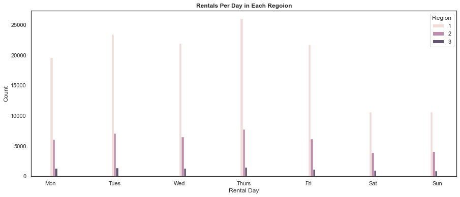